# Exercise 1

Ada Olsdatter Hagaseth and Isak Hammer

2/10/2022

```r
## Libraries used in Project
library(ggplot2)
library(knitr)
knitr::opts_chunk$set(echo = TRUE, warning=FALSE, message=FALSE)
opts_chunk$set(tidy.opts=list(width.cutoff=60),tidy=TRUE)
```

# Problem A

## Question A1

We first want to write an R function that generates samples from a exponential distribution with rate parameter $\lambda$. We know that the cumulative exponential distrobution takes the form
$$F(x;\lambda) = 1 - \lambda e ^{-\lambda x}, \quad x \ge 0$$

Computing the inverse cumulative function exploiting the uniform distribution $U \sim Unif(0,1)$ we can get
$$X = F^{-1}(u) = - ln (u)/\lambda, \quad 0 \leq u \leq 1$$

We now want to show that this is true using simulation from the inverse cumulative distribution

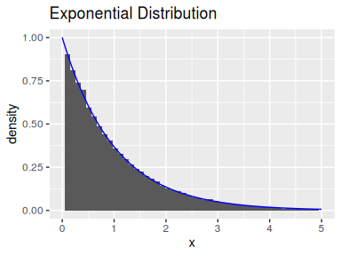

```r
library(ggplot2)
# n: number of samples to generate
# rate: the rate
# expdist returns a vector with generated random numbers from exponential distribution

expdist <- function(rate, n) {
   u <- runif(n)
   x <-  -log( (1/rate)*( 1 - u))/rate
   list = list(x, u)
   return(list)
}

n <- 60000
lambda <- 1
outval <- expdist(lambda, n)
x = outval[[1]]
y = outval[[2]]

ggplot(data.frame(x=x))+geom_histogram(aes(x=x, y = ..density..),
bins = 50)  +geom_line(data = data.frame(x=x,y=dexp(x, rate = 1)),
aes(x=x, y=y) ,
color = "blue")+xlim(0,5)+ labs(title = "Exponential Distribution")
```

```r
#color = "blue")+xlim(0,5)
#plot(x, data)
```

From the plot one can see that the exponential distribtion that we generated and the exponential distribution in R closely follow each other, which means that our implementation is correct.

# Problem B

## Question B1

The acceptance probability has the form
$$P(U\leq\frac{f(x)}{cg(x)}) = \int_{-\infty}^{\infty}\frac{f(x)}{cg(x)}g(x)dx = \int_{-\infty}^{\infty}\frac{f(x)}{c}dx = \frac{1}{c}$$

where $c$ is such that $\frac{f(x)}{g(x)}\leq c$. To find $c$, consider the expression $f(x)\leq cg(x)$. Then we get (for the nontrivial cases when $x>0$)

$$\frac{1}{\Gamma(\alpha)}x^{\alpha-1}e^{-x}\leq \begin{cases}
c\frac{e\alpha}{e+\alpha}x^{\alpha-1}, 0 < x < 1\\
c\frac{e\alpha}{e+\alpha}e^{-x}, x \geq 1\\
\end{cases}$$
Rearranging the inequalities and using that $e^{-x}$ and $x^{\alpha-1}$ are decreasing functions, we get the following upper bound for $c$:

$$c\geq\frac{1}{\Gamma(\alpha)}\frac{e+\alpha}{e\alpha}$$
So we choose $c = \frac{1}{\Gamma(\alpha)}\frac{e+\alpha}{e\alpha}$ to satisfy our initial inequality. The acceptance probability is then $\frac{1}{c} = \frac{\Gamma(\alpha)e\alpha}{e+\alpha}$.

## Question B1b

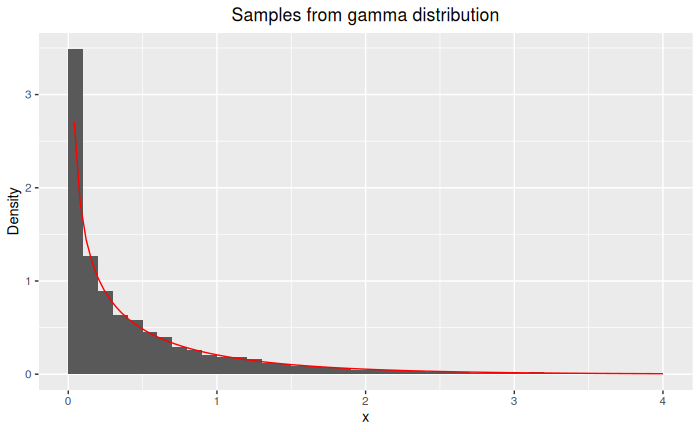

```r
# f_b1 returns the value of f in this exercise, a gamma distribution
f_b1 <- function(alpha, x) {
  gamma = (1/gamma(alpha))*x^(alpha-1)*exp(-x)
  return((gamma)*(x>0))
}

# acceptance_criterion returns the alpha to accept/reject in rejection sampling
acceptance_criterion <- function(alpha, x) {
  const = (exp(1)+alpha)/(gamma(alpha)*exp(1)*alpha)
  alpha = f_b1(alpha, x)/(const*g_test(alpha, x))
  return(alpha)
}

# rejection_b generates samples from f by rejection sampling
# n: number of samples to generate
# alpha: shape parameter
rejection_b <- function(alpha, n) {
  out = 1:n

  for (i in 1:n) {
    finished = 0
    while(finished==0) {
      u = runif(1)
      x = dist1(alpha, 1)[[1]]
      acceptance = acceptance_criterion(alpha, x)
      if(u <= acceptance) {
        out[i] = x
        finished = 1
      }
    }
  }
  return(out)
}


# f_testb is the theoretical function to test the algorithm with
f_testb = function(x, alpha) {
  gamma = (1/gamma(alpha))*x^(alpha-1)*exp(-x)
  return((gamma)*(x>0))
}

n = 10000
alpha = 0.5


library(ggplot2)
samples_b1 <- rejection_b(alpha, n)
x <- seq(0,4,0.001)
data_b1 <- data.frame("samples_b1"=samples_b1)


ggplot(data=data_b1, aes(data_b1$samples_b1)) +
geom_histogram(aes(y=..density..), breaks = seq(0, 4, by = 0.1)) +theme(plot.title = element_text(hjust = 0.5))+
xlim(c(0,4)) + labs(title="Samples from gamma distribution", x="x", y="Density") +
stat_function(fun = f_testb, args = list(alpha), color = "red")
```

## Question B2a

We can define the domain
$$C_f = \Big \{ (x_1, x_2) : 0 \le x_1 \le \sqrt{f^{*}\Big(\frac{x_2}{x_1}\Big)} \Big \}$$
where
$$f(x) =
\begin{cases}
x^{\alpha -1}e^{-x}, \quad & x> 0 \\
0, \quad & x\le 0 \\
\end{cases}$$
We now want to define some upper and lower bounds such that
$$\begin{align}
a &= \sqrt{{sup}_x f(x) } = \sqrt{f(\alpha -1)} \\
b_{+} &= \sqrt{{sup}_{x \ge 0} x^2 f(x) } = \sqrt{(\alpha +1)^2 f(\alpha +1)}\\
b_{-} &= \sqrt{{sup}_{x \le 0} x^2 f(x) } = 0
\end{align}$$

The supremum for $a$ and $b_{+}$ can easily be derived by finding extremal points of the function using differentiation and $b_{-}$ follows from $f(x) = 0$ for $x\le 0$.

## Question B2b

To sample from the gamma distribution for large values of $\alpha$, we use the ratio of uniforms method with the values of $a, b_{-}$ and $b_{+}$ as above. To avoid computational errors following large numbers, we use a log transform. To sample from the uniform distribution between 0 and $a_-$ and between 0 and $b_+$, we use that

$$x_1 = a\cdot u_1\\
x_2 = b_+\cdot u_2$$
which is a transform from the standard uniform variables $u_1, u_2$ to a uniform distribution between 0 and some other limit. In the log scales, this becomes

$$\log(x_1) = \log(a) + \log(u_1)\\
\log(x_2) = \log(b_+) + \log(u_2)$$
The acceptance criterion is then

$$x_1 \leq \sqrt{\frac{x_2^{\alpha-1}e^{-x_2}}{x_1^{\alpha-1}e^{-x_2}}}$$
and on the log scale we get
$$\log(x_1) \leq \frac{1}{2}(\alpha-1)(\log(x_2)-\log(x_1))-e^{\log(x_2)-log(x_1)}$$

```r
n <- 10000
# f_gamma the kernel of a gamma function
f_gamma <- function(x, alpha){
  return (x^(alpha - 1 )*exp(-x)*(x>0))
}

alpha <- 400

# gamma_b2b2 samples from gamma distribution with large alpha
gamma_b2b2 <- function(alpha, n){
  x = 1:n
  loga = 0.5*((alpha-1)*log(alpha-1)+(1-alpha))
  logb = 0.5*((alpha+1)*log(alpha+1)-1-alpha)
  trials = 1

  for (i in 1:n){
    logx1 = loga + log(runif(1))
    logx2 = logb + log(runif(1))
    f_condition = 0.5*((alpha-1)*(logx2-logx1)-exp(logx2-logx1))
    while(logx1 > f_condition){
    logx1 = loga + log(runif(1))
    logx2 = logb + log(runif(1))
    f_condition = 0.5*((alpha-1)*(logx2-logx1)-exp(logx2-logx1))
    trials = trials + 1
    }

     x[i] = exp(logx2-logx1)
  }
  return(cbind(x, trials-1))
}


samples_b2b = gamma_b2b2(alpha, n)[,1]
hist(samples_b2b, breaks = 40, freq = FALSE, main = bquote("Histogram of gamma distribution when "~alpha == .(alpha)))
curve(dgamma(x, alpha, 1), col = "red", lwd = 2, add=TRUE)
```

[output not shown]

```r
test_tries <- function(n) {
  alpha = seq(2,2000,10)
  tryvector = 1:length(alpha)
  for (i in 1:length(alpha)) {
    tries = gamma_b2b2(alpha[i], n)[,2][1]
    tryvector[i] = tries
  }
  return(cbind(alpha, tryvector))

}

test_try = test_tries(1000)
```

## Question B3

We want to generate $n$ samples of the gamma distribution

$$f(x) = \frac{\beta^{\alpha}}{\Gamma (\alpha)} x^{\alpha -1} e^{-\beta}$$

for $\alpha > 0$ and $\beta > 0$. We use that $Y = \frac{X}{\beta}$ is Gamma($\alpha$, $\beta$) distributed if $X$ is Gamma($\alpha$) distributed. To show this, use the moment generating function of $Y$ and the properties of moment generating functions.

$$M_Y(t) = M_X\bigg(\frac{t}{\beta}\bigg) = \bigg(1-\frac{t}{\beta}\bigg)^{-\alpha}$$
which we recognize as the MGF of a Gamma($\alpha$, $\beta$) variable. When $\alpha = 1$, we recognize this as the MGF of an Exponential($\beta$) distribution, so therefore we can sample from the exponential distribution in this case. We use the rejection sampling algorithm for $\alpha \in (0,1)$ and the ratio of uniforms algorithm for $\alpha>1$.

## Question B4a

We want to show that if $x \sim \text{Gamma}(\alpha, 1)$ and $y \sim \text{Gamma}(\beta, 1)$ are independent, then $z = \frac{x}{x+y}$ is $\text{Beta}(\alpha, \beta$) distributed. Define $v = x + y$ such that $x = zv$ and $y = v(1-z)$. Then the jacobian of the transformation is $v$, so by using the transformation of variables formula, the joint distribution of $z$ and $v$ becomes

$$f_{zv}(z,v) = \frac{v}{\Gamma(\alpha)\Gamma(\beta)}(vz)^{\alpha-1}(v(1-z))^{\beta-1}e^{-v}$$

which can be written as

$$\frac{v^{\alpha+\beta-1}}{\Gamma(\alpha)\Gamma(\beta)}z^{\alpha-1}(1-z)^{\beta-1}e^{-v}$$
and we see that this is just a gamma distribution and a beta distribution multiplied, so $v \sim \text{Gamma}(\alpha+\beta, 1)$ and $z \sim \text{Beta} (\alpha, \beta)$.

## Question B4b

To sample from a Beta($\alpha$, $\beta$ ) distribution, we use the result above.

# Problem C

## Question C1

The estimate of the probability $P(X>4)$ is 410^{-5}. The confidence interval for $\theta$ is [8.011123110^{-7}, 7.919888810^{-5}].

Question C 2 We want to use importance sampling to estimate $P(X>4)$. To determine the normalizing constant $c$, we use that the density $g(x)$ must integrate to 1, and we get that $c = e^8$. To estimate $P(X>4)$ by importance sampling, we can estimate $\int f(x)h(x)dx$ with $\frac{1}{N}\sum_{i=1}^N\frac{f(x_i)h(x_i)}{g(x_i)}$, where $x_i$ are sampled from the distribution $g(x)$, and in our case this is done by inversion sampling.

The function we want to sample from is
$$g(x)= \begin{cases}
cxe^{-0.5x^2} & x > 4 \\
0 & \text{otherwise }
\end{cases}$$
By integrating from $t=4$ to an arbitrary $x$, we find that the cumulative distribution is

$$G(x) = 1-e^{8-0.5x^2}$$
Solving this equation for $x$ we get

$$G^{-1}(u) = \sqrt{16-2log(1-u)}$$

The estimate of $P(X>4)$ with importance sampling is 3.167736510^{-5}. The confidence interval for $\theta$ with importance sampling is [3.167736510^{-5}, 3.167736510^{-5}]. Compared to the confidence interval for Monte Carlo integration [8.011123110^{-7}, 7.919888810^{-5}], we see that the confidence interval from importance sampling is smaller, and therefore we prefer importance sampling over Monte Carlo integration for this problem.

## Question 3Cb

Now we use the function above to estimate the probability $\theta = P(X>4)$ and the variance of $\theta$. Because the function gives pairs of random variables, we will get a similar result if we use antithetic variables with $n = 5\cdot10^4$ as if we use importance sampling with $n = 10^5$ variables.

The estimate of the probability $P(X>4)$ with antithetic variables is 3.167024810^{-5}. The confidence interval is [3.167024810^{-5}, 3.167024810^{-5}]. We see that as expected, the precision of the antithetic variables and the importance sampling is similar. We must use a value of $n$ that is half as big for antithetic variables as for importance sampling because antithetic variables produces pairs of variables, and therefore the total amount of simulated samples will be the same in the end.

# Problem D

## Question D1

We want to sample from

$$f(\theta|\mathbf{y})\propto(2+\theta)^{y_1}(1-\theta)^{y_2+y_3}\theta^{y_4}$$
by using rejection sampling and using $g(\theta) = U(0,1)$ as the proposal density. We use the maximum of $f$ as the constant $c$ in rejection sampling, to ensure $\frac{f(\theta|y)}{g(\theta)} \leq c$.

## Question D3

The overall acceptance probability is
$$P(U\leq\frac{f(\theta)}{cg(\theta)}) = \int_{-\infty}^{\infty}\frac{f(\theta)}{cg(\theta)}g(\theta)d\theta = \int_{-\infty}^{\infty}\frac{f(\theta)}{c}d\theta = \frac{1}{c}$$
which implies that the number of trials to simulate one sample is $c$.

We want to count how many trials we need to simulate one sample, and we check it with the theoretical value of c. We just copy the algorithm from before and add a counter.

The number of trials in the simulation until one acceptance is 7.7659, and the numerical calcualtion of the theoretical number of trials is 7.7993075.

## Question D4

The simulated expected value is 0.5961526, and the numerical value is 0.5959316. We see that they are equal.